# delay

Rica Rebusit

2023-07-22

I will be using this dataset from Kaggle -> [Click Me!](https://www.kaggle.com/datasets/ulrikthygepedersen/airlines-delay?resource=download&select=airlines_delay.csv) to predict if a flight will be delayed based on:

- **Flight**: Flight ID
- **Time**: Time of departure
- **Length**: Length of flight
- **Airline**: Airline ID
- **AirportFrom**: Which airport the flight flew from
- **AirportTo**: Which airport the flight flew to
- **DayOfWeek**: Day of the week of flight
- **Class**: Whether the flight was delayed depicted by (1) and (0) if not delayed

This dataset also has 539382 observations

# Loading Necessary Libraries and Importing dataset

```r
library(tidyverse)
library(randomForest)
delay <- read.csv("~/Documents/delay-prediction/airlines_delay.csv")
```

# Checking the Data and EDA

Looking at the first 6 rows

```r
head(delay)
```

```
##   Flight Time Length Airline AirportFrom AirportTo DayOfWeek Class
## 1   2313 1296    141      DL         ATL       HOU         1     0
## 2   6948  360    146      OO         COS       ORD         4     0
## 3   1247 1170    143      B6         BOS       CLT         3     0
## 4     31 1410    344      US         OGG       PHX         6     0
## 5    563  692     98      FL         BMI       ATL         4     0
## 6   3692  580     60      WN         MSY       BHM         4     0
```

Checking the data types of each variable

```r
str(delay)
```

```
## 'data.frame':    539382 obs. of  8 variables:
##  $ Flight     : num  2313 6948 1247 31 563 ...
##  $ Time       : num  1296 360 1170 1410 692 ...
##  $ Length     : num  141 146 143 344 98 60 239 80 105 108 ...
##  $ Airline    : chr  "DL" "OO" "B6" "US" ...
##  $ AirportFrom: chr  "ATL" "COS" "BOS" "OGG" ...
##  $ AirportTo  : chr  "HOU" "ORD" "CLT" "PHX" ...
##  $ DayOfWeek  : int  1 4 3 6 4 4 4 3 7 3 ...
##  $ Class      : int  0 0 0 0 0 0 0 0 0 0 ...
```

Looking at unique values of categorical variables

```r
unique(delay$Airline)
```

```
##  [1] "DL" "OO" "B6" "US" "FL" "WN" "CO" "AA" "YV" "EV" "XE" "9E" "OH" "UA" "MQ"
## [16] "AS" "F9" "HA"
```

```r
unique(delay$AirportFrom)
```

```
##   [1] "ATL" "COS" "BOS" "OGG" "BMI" "MSY" "EWR" "DFW" "BWI" "CRW" "LGB" "BIS"
##  [13] "CLT" "IAH" "LAX" "JAX" "SAV" "CLE" "FLL" "SAN" "BHM" "ROC" "DTW" "STT"
##  [25] "AUS" "DCA" "PHX" "EYW" "IND" "JFK" "ORD" "PBI" "SFO" "MIA" "DSM" "SLC"
##  [37] "PHL" "BZN" "GRB" "MBS" "SBA" "TYS" "MSP" "DEN" "SAT" "BUF" "RIC" "SEA"
##  [49] "PDX" "LAS" "IAD" "HNL" "BDL" "MOT" "PSE" "CPR" "SNA" "STL" "CVG" "PIT"
##  [61] "HSV" "SGF" "RDU" "MEM" "KOA" "ELP" "SJU" "JAN" "AEX" "LGA" "RSW" "MDT"
##  [73] "GUC" "MKE" "CAE" "GRR" "FAR" "LIT" "OMA" "BNA" "EVV" "RDD" "OKC" "ITO"
##  [85] "SJC" "MCO" "LBB" "CSG" "OAK" "PHF" "ABQ" "SMF" "FAY" "ABI" "MSO" "MFE"
##  [97] "GEG" "MSN" "TPA" "DAY" "RNO" "PVD" "ALB" "CHO" "ONT" "LIH" "PSP" "LAN"
## [109] "LEX" "XNA" "GJT" "CMH" "GSO" "PSC" "SYR" "AVL" "MHT" "GRK" "MCI" "TXK"
## [121] "LRD" "ABE" "LWB" "ERI" "DAL" "ANC" "TUS" "ROA" "MOD" "JNU" "SBP" "CDV"
## [133] "TUL" "FSD" "FNT" "BTV" "FCA" "GNV" "RAP" "MDW" "FWA" "BUR" "PNS" "RST"
## [145] "HOU" "BOI" "CRP" "BRO" "ATW" "SHV" "SMX" "RDM" "ORF" "GPT" "KTN" "ICT"
## [157] "SAF" "CAK" "IDA" "MQT" "VPS" "CHS" "MAF" "HPN" "AVP" "AZO" "TRI" "GSP"
## [169] "HDN" "MLU" "EUG" "AMA" "MHK" "ISP" "CID" "MOB" "BGR" "SRQ" "MLI" "EKO"
## [181] "LFT" "TOL" "ECP" "PSG" "SBN" "FAT" "ELM" "YUM" "CLD" "FAI" "ASE" "BTR"
## [193] "BQK" "COU" "MRY" "CEC" "CWA" "PWM" "FLG" "TLH" "SDF" "BFL" "CHA" "ACV"
## [205] "MGM" "ROW" "GTR" "EWN" "ILM" "OTZ" "SGU" "OTH" "CMX" "SWF" "BET" "GTF"
## [217] "CMI" "MFR" "JAC" "DLH" "ABY" "MTJ" "SCC" "DRO" "TEX" "FSM" "COD" "GGG"
## [229] "DBQ" "GFK" "BKG" "AGS" "BTM" "DHN" "TYR" "EGE" "PIH" "VLD" "MEI" "SIT"
## [241] "MLB" "PAH" "YAK" "DAB" "HLN" "PIA" "SPI" "GCC" "IPL" "TVC" "OAJ" "EAU"
## [253] "BGM" "MYR" "HRL" "MKG" "SUN" "LSE" "CIC" "OME" "ITH" "LNK" "BIL" "CYS"
## [265] "LCH" "BQN" "WRG" "BRW" "SPS" "RKS" "TWF" "LMT" "ACT" "PLN" "ACY" "ADK"
## [277] "SJT" "IYK" "LWS" "BLI" "SCE" "MMH" "LYH" "GUM" "CDC" "ADQ" "HTS" "PIE"
## [289] "STX" "FLO" "UTM" "CLL" "ABR"
```

```r
unique(delay$AirportTo)
```

```
##   [1] "HOU" "ORD" "CLT" "PHX" "ATL" "BHM" "DFW" "MEM" "GRR" "PBI" "MCO" "SFO"
##  [13] "DEN" "YUM" "BWI" "HPN" "EWR" "JFK" "MKE" "OAK" "IAH" "CLE" "SYR" "SJU"
##  [25] "BDL" "SAN" "DTW" "PSP" "DCA" "LGA" "STL" "FAY" "MSP" "BUF" "LAS" "SGU"
##  [37] "SLC" "GJT" "LAX" "VPS" "FAR" "RKS" "BOS" "ANC" "SNA" "ONT" "RNO" "JAX"
##  [49] "GSP" "CVG" "TPA" "SEA" "LEX" "SMF" "CAE" "STT" "DAY" "MDW" "RSW" "ITO"
##  [61] "IAD" "ICT" "HNL" "MIA" "CRW" "RDU" "MHT" "FAT" "CAK" "COS" "DAL" "TYS"
##  [73] "PHL" "ABI" "MOB" "SDF" "SAV" "MDT" "LIT" "TUL" "ACV" "BNA" "MCI" "MSY"
##  [85] "FLL" "PVD" "OKC" "ECP" "PHF" "AUS" "RIC" "LIH" "ABQ" "JAN" "PIT" "BMI"
##  [97] "BTV" "RAP" "MRY" "CSG" "SHV" "FAI" "SJC" "PIA" "SBN" "IND" "SGF" "ACT"
## [109] "SRQ" "ROC" "CHO" "JAC" "SAT" "FWA" "OMA" "PDX" "CMH" "PWM" "CID" "TRI"
## [121] "ORF" "GTF" "TUS" "MHK" "BUR" "MLU" "CEC" "TEX" "MBS" "DSM" "HRL" "LFT"
## [133] "ELP" "AEX" "CPR" "LBB" "MYR" "ALB" "COU" "LSE" "CHA" "MLI" "GEG" "AZO"
## [145] "MFR" "BTR" "FLG" "KTN" "PSC" "GSO" "OGG" "MSN" "GPT" "PNS" "RDM" "BZN"
## [157] "DLH" "CRP" "TXK" "KOA" "MQT" "MAF" "TLH" "XNA" "CWA" "SBP" "BFL" "DRO"
## [169] "WRG" "DHN" "SPS" "AMA" "EGE" "BET" "FCA" "EUG" "EVV" "AVL" "HSV" "PIE"
## [181] "MLB" "SWF" "ASE" "BGM" "MSO" "ADK" "GRK" "SUN" "SBA" "LGB" "CHS" "GNV"
## [193] "MOT" "LAN" "LNK" "OME" "OTH" "ISP" "FNT" "EAU" "ILM" "BRW" "LCH" "IYK"
## [205] "MKG" "HDN" "BRO" "GRB" "FSD" "LRD" "RDD" "SPI" "ROA" "IPL" "EYW" "SAF"
## [217] "LWS" "AGS" "CMX" "ATW" "MGM" "GGG" "BOI" "FLO" "COD" "ACY" "CMI" "JNU"
## [229] "AVP" "ERI" "TYR" "DAB" "TVC" "FSM" "IDA" "MFE" "EKO" "ABE" "PAH" "LMT"
## [241] "YAK" "HLN" "MMH" "ITH" "LYH" "BIL" "EWN" "SMX" "MEI" "OAJ" "SCE" "CLD"
## [253] "BIS" "GFK" "MTJ" "BQN" "BQK" "GTR" "CDV" "BKG" "PIH" "ROW" "PLN" "TWF"
## [265] "ELM" "GCC" "CYS" "CDC" "ABY" "VLD" "MOD" "STX" "OTZ" "HTS" "BTM" "PSE"
## [277] "SCC" "RST" "DBQ" "ADQ" "PSG" "SIT" "GUC" "LWB" "BGR" "CIC" "GUM" "UTM"
## [289] "CLL" "TOL" "SJT" "BLI" "ABR"
```

Variable **Class** is a integer when we want it to be a factor in order to predict so convert **Class** to a factor

```r
delay$Class <- as.factor(delay$Class)
str(delay$Class)
```

```
##  Factor w/ 2 levels "0","1": 1 1 1 1 1 1 1 1 1 1 ...
```

Checking to see if there are NA values

```r
colSums(is.na(delay))
```

```
##      Flight        Time      Length     Airline AirportFrom   AirportTo
##           0           0           0           0           0           0
##   DayOfWeek       Class
##           0           0
```

Dropping column **Flight** because there is no significance for the flight ID

```r
delay <- delay %>%
  select(-"Flight")
head(delay)
```

```
##   Time Length Airline AirportFrom AirportTo DayOfWeek Class
## 1 1296    141      DL         ATL       HOU         1     0
## 2  360    146      OO         COS       ORD         4     0
## 3 1170    143      B6         BOS       CLT         3     0
## 4 1410    344      US         OGG       PHX         6     0
## 5  692     98      FL         BMI       ATL         4     0
## 6  580     60      WN         MSY       BHM         4     0
```

Now time to do some exploration by comparing **Airline** to other variables. First checking the count of delays in each airline

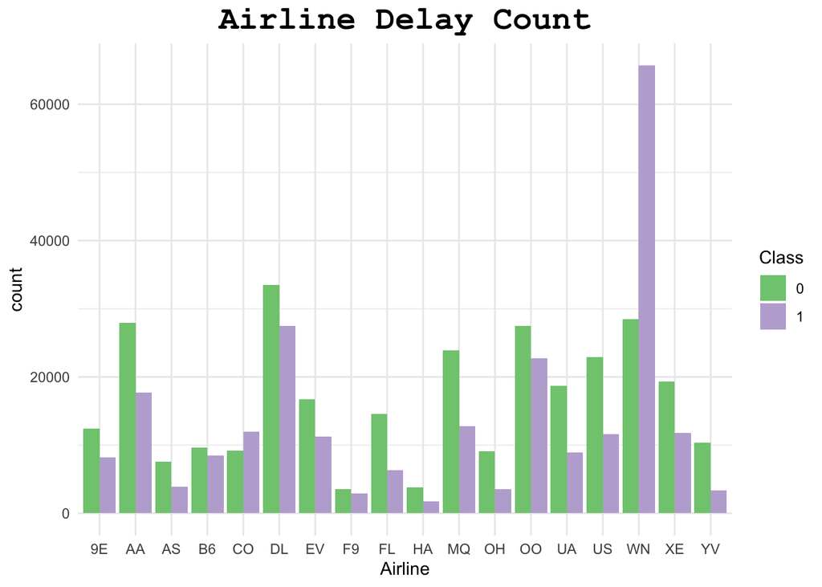

```r
ggplot(delay, aes(Airline, fill = Class)) + geom_bar(position="dodge") + theme_minimal() + scale_fill_brewer(palette = "Accent") + labs(title = "Airline Delay Count") + theme(plot.title = element_text(family = "Courier New", size = 20, face = "bold", hjust = 0.5))
```

It seems like WN has more delays

```r
count(filter(delay, Class == 1, Airline == "WN")) #WN has 65657 delays
```

```
##       n
## 1 65657
```

Checking the count of delays

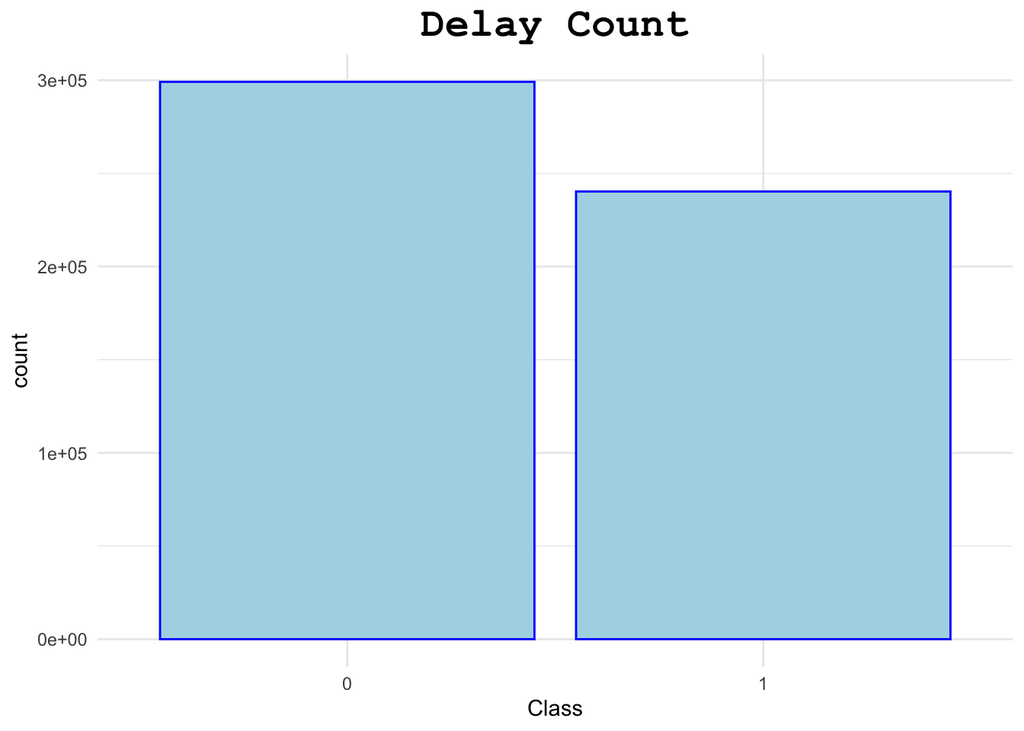

```r
ggplot(delay, aes(Class)) + geom_bar(fill = "Lightblue", color = "Blue") + theme_minimal() + labs(title = "Delay Count") + theme(plot.title = element_text(family = "Courier New", size = 20, face = "bold", hjust = 0.5))
```

More no delays than delays

Looking at time departure

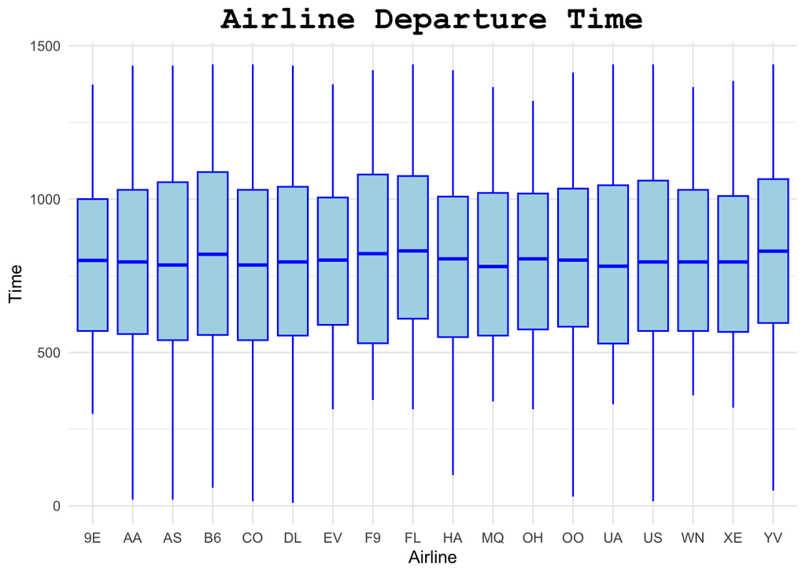

```r
ggplot(delay, aes(Airline, Time)) + geom_boxplot(fill = "Lightblue", color = "Blue") + theme_minimal() + labs(title = "Airline Departure Time") + theme(plot.title = element_text(family = "Courier New", size = 20, face = "bold", hjust = 0.5))
```

All airlines seem to departure at the same time

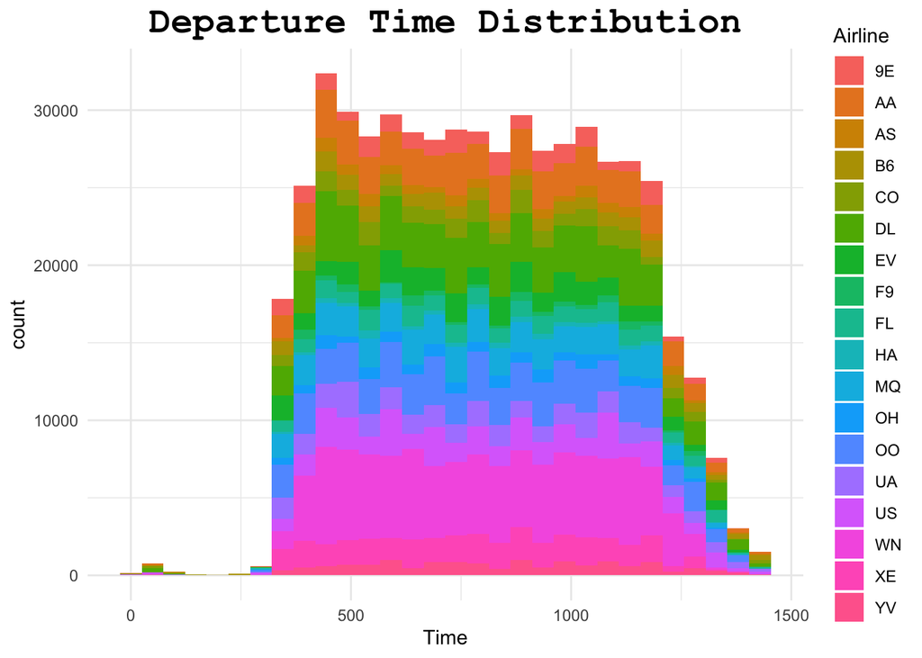

```r
ggplot(delay, aes(Time, fill = Airline)) + geom_histogram(position="stack") + theme_minimal() + labs(title = "Departure Time Distribution") + theme(plot.title = element_text(family = "Courier New", size = 20, face = "bold", hjust = 0.5))
```

Looking at length of flight

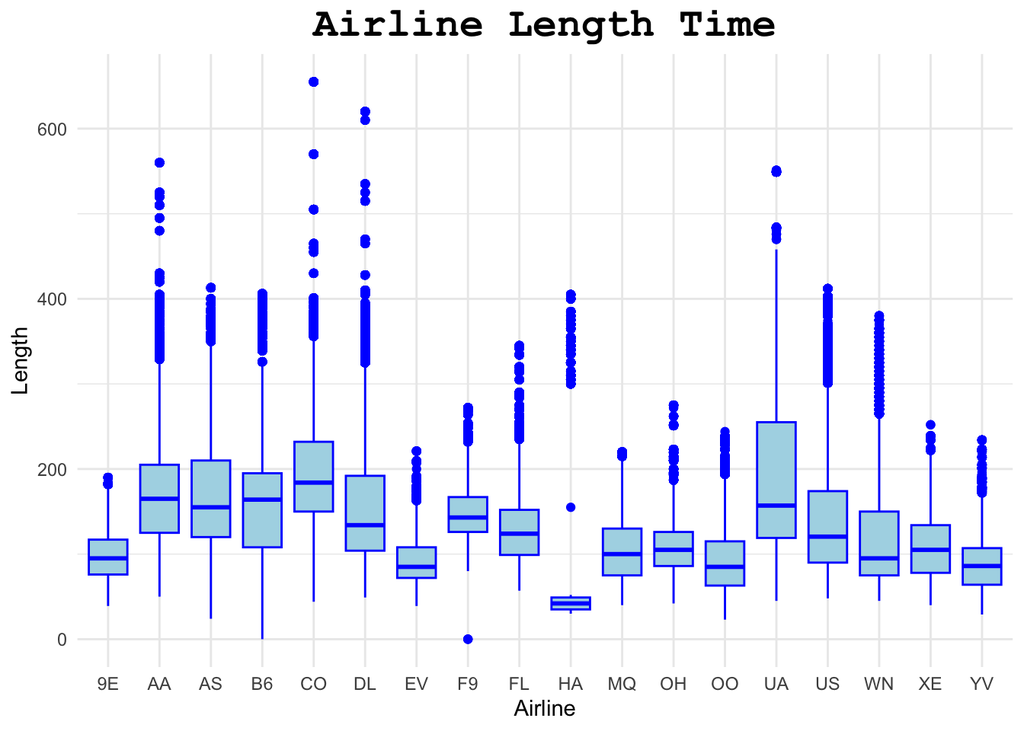

```r
ggplot(delay, aes(Airline, Length)) + geom_boxplot(fill = "Lightblue", color = "Blue") + theme_minimal() + labs(title = "Airline Length Time") + theme(plot.title = element_text(family = "Courier New", size = 20, face = "bold", hjust = 0.5))
```

Seeing which the airline with max length and min length

```r
delay$Airline[which.max(delay$Length)] #CO
```

```
## [1] "CO"
```

```r
delay$Length[which.max(delay$Length)] #655
```

```
## [1] 655
```

```r
head(filter(delay, Length == 655))
```

```
##   Time Length Airline AirportFrom AirportTo DayOfWeek Class
## 1  710    655      CO         EWR       HNL         4     0
## 2  710    655      CO         EWR       HNL         2     1
## 3  710    655      CO         EWR       HNL         6     1
## 4  815    655      CO         EWR       HNL         6     1
## 5  815    655      CO         EWR       HNL         5     1
## 6  710    655      CO         EWR       HNL         3     1
```

So airline CO departing from EWR flying to HNL has the greatest flight length

```r
delay$Airline[which.min(delay$Length)] #F9
```

```
## [1] "F9"
```

```r
delay$Length[which.min(delay$Length)] #0
```

```
## [1] 0
```

```r
head(filter(delay, Length == 0))
```

```
##   Time Length Airline AirportFrom AirportTo DayOfWeek Class
## 1  635      0      F9         DEN       MSP         6     0
## 2  375      0      F9         MSP       DEN         7     0
## 3  851      0      F9         MSP       DEN         6     0
## 4 1060      0      B6         BOS       SEA         7     1
```

Airline B6 also has flight length 0. Maybe the flights were cancelled and both looks like to be towards the weekend.

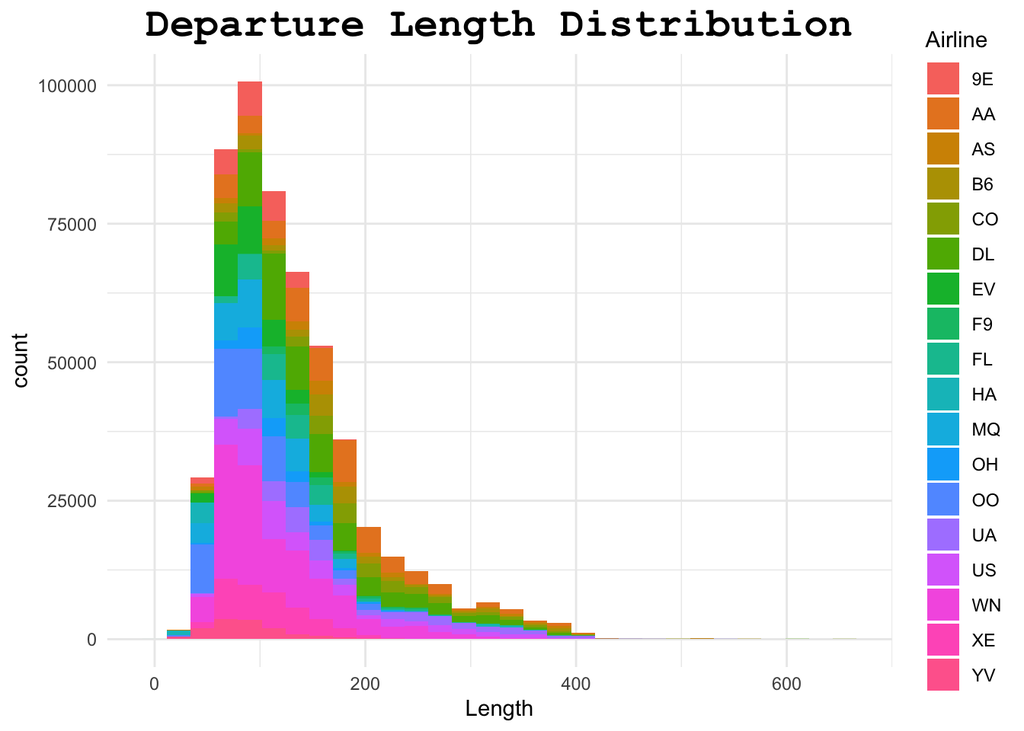

```r
ggplot(delay, aes(Length, fill = Airline)) + geom_histogram(position="stack") + theme_minimal() + labs(title = "Departure Length Distribution") + theme(plot.title = element_text(family = "Courier New", size = 20, face = "bold", hjust = 0.5))
```

Right skewed

Checking which day of the week is most popular for flights

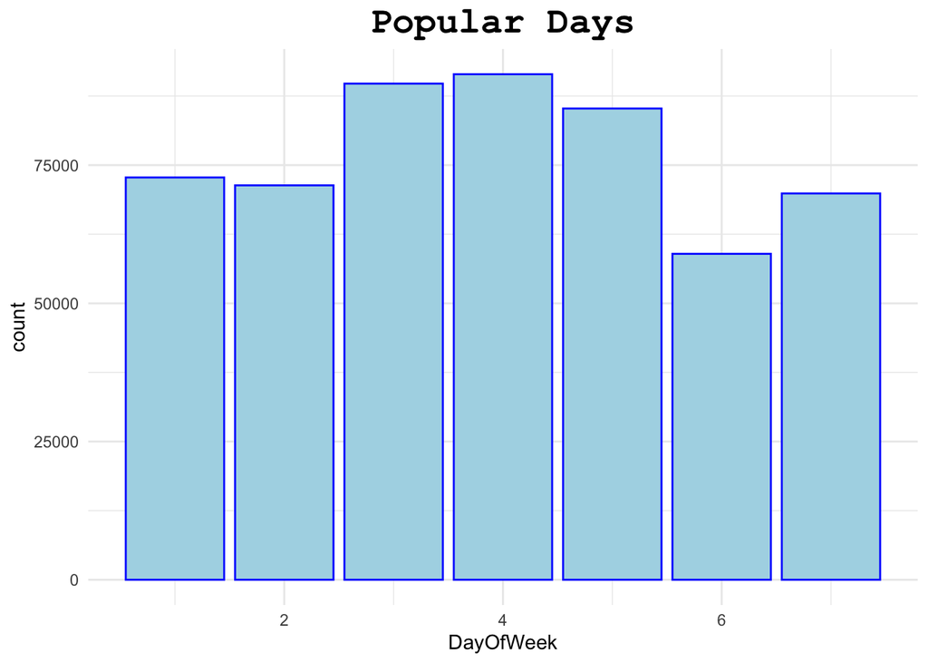

```r
ggplot(delay, aes(DayOfWeek)) + geom_bar(fill = "Lightblue", color = "Blue") + theme_minimal() + labs(title = "Popular Days") + theme(plot.title = element_text(family = "Courier New", size = 20, face = "bold", hjust = 0.5))
```

During the middle of the weeks is most popular for flights

Now that we explored the data, dropped a column, and changed **Class** variable type, let’s start to predict!

# Train and Test Data

```r
tra.tes <- sample(nrow(delay), 0.7*nrow(delay))
train <- delay[tra.tes, ]
test <- delay[-tra.tes, ]
```

# Logistic Regression

```r
#logistic <- glm(Class ~., data = train, family = binomial)
```